# MovieLens Project Questions

### `Project - MovieLens Data Analysis`

The GroupLens Research Project is a research group in the Department of Computer Science and Engineering at the University of Minnesota. The data is widely used for collaborative filtering and other filtering solutions. However, we will be using this data to act as a means to demonstrate our skill in using Python to “play” with data.

### `Objective:`

- To implement the techniques learnt as a part of the course.

### `Learning Outcomes:`

- Exploratory Data Analysis
- Visualization using Python
- Pandas – groupby, merging

### `Domain`

- Internet and Entertainment

**Note that the project will need you to apply the concepts of groupby and merging extensively.**

### `Datasets Information:`

*rating.csv:* It contains information on ratings given by the users to a particular movie.

- user id: id assigned to every user
- movie id: id assigned to every movie
- rating: rating given by the user
- timestamp: Time recorded when the user gave a rating

*movie.csv:* File contains information related to the movies and their genre.

- movie id: id assigned to every movie
- movie title: Title of the movie
- release date: Date of release of the movie
- Action: Genre containing binary values (1 - for action 0 - not action)
- Adventure: Genre containing binary values (1 - for adventure 0 - not adventure)
- Animation: Genre containing binary values (1 - for animation 0 - not animation)
- Children’s: Genre containing binary values (1 - for children's 0 - not children's)
- Comedy: Genre containing binary values (1 - for comedy 0 - not comedy)
- Crime: Genre containing binary values (1 - for crime 0 - not crime)
- Documentary: Genre containing binary values (1 - for documentary 0 - not documentary)
- Drama: Genre containing binary values (1 - for drama 0 - not drama)
- Fantasy: Genre containing binary values (1 - for fantasy 0 - not fantasy)
- Film-Noir: Genre containing binary values (1 - for film-noir 0 - not film-noir)
- Horror: Genre containing binary values (1 - for horror 0 - not horror)
- Musical: Genre containing binary values (1 - for musical 0 - not musical)
- Mystery: Genre containing binary values (1 - for mystery 0 - not mystery)
- Romance: Genre containing binary values (1 - for romance 0 - not romance)
- Sci-Fi: Genre containing binary values (1 - for sci-fi 0 - not sci-fi)
- Thriller: Genre containing binary values (1 - for thriller 0 - not thriller)
- War: Genre containing binary values (1 - for war 0 - not war)
- Western: Genre containing binary values (1 - for western - not western)

*user.csv:* It contains information of the users who have rated the movies.

- user id: id assigned to every user
- age: Age of the user
- gender: Gender of the user
- occupation: Occupation of the user
- zip code: Zip code of the use

**`Please provide you insights wherever necessary.`**

### 1. Import the necessary packages - 2.5 marks

```python
import numpy as np # Adding support for large multi-dimenstional arrays and matrices
import pandas as pd # Adding support for manipulating datasets(tables)
import matplotlib.pyplot as plt # Matplotlib - A plotting library from extension of Numpy.
                                # Matplotlib.pyplot - collection of command style functions make matplotlib work like MATLAB, it is stateful, in that it keeps track of the current figure and the plotting area, and the plotting functions are directed to the current axes
import seaborn as sns
sns.set_style('darkgrid')
sns.set(color_codes=True) # adds a nice background to the graphs
%matplotlib inline
# tells python to actually display the graphs

sns.set(rc={'figure.figsize':(30,30)})

from IPython.core.interactiveshell import InteractiveShell
InteractiveShell.ast_node_interactivity = "all"
```

### 2. Read the 3 datasets into dataframes - 2.5 marks

```python
users = pd.read_csv('user.csv')
print(type(users)) # users is of Type 'pandas.core.frame.DataFrame'
movies = pd.read_csv('movie.csv')
ratings = pd.read_csv('rating.csv')
```

```
<class 'pandas.core.frame.DataFrame'>
```

### 3. Apply info, shape, describe, and find the number of missing values in the data - 5 marks

- Note that you will need to do it for all the three datasets seperately

### 3.1 Users

```python
users.shape # Returns the size of the Table

users.info() # describes the Table structure

users.describe() # Descriptive statistics include those that summarize the central tendency, dispersion and shape of a dataset’s distribution, excluding NaN values.

# users.isna() returns a dataFrame with results checking for each value in it
# users.isna().any() returns a series with results checking for each column has any missing data
# users.isna().any().any() check to see if there are any missing values
hasMissingValues = users.isna().any().any()
if hasMissingValues:
    print('There are missing Values in this dataframe')
else:
    print('There are no missing Values in this dataframe')
```

```
(943, 5)
```

```
<class 'pandas.core.frame.DataFrame'>
RangeIndex: 943 entries, 0 to 942
Data columns (total 5 columns):
 #   Column      Non-Null Count  Dtype
---  ------      --------------  -----
 0   user id     943 non-null    int64
 1   age         943 non-null    int64
 2   gender      943 non-null    object
 3   occupation  943 non-null    object
 4   zip code    943 non-null    object
dtypes: int64(2), object(3)
memory usage: 37.0+ KB
```

|  | user id | age |
| --- | --- | --- |
| count | 943.000000 | 943.000000 |
| mean | 472.000000 | 34.051962 |
| std | 272.364951 | 12.192740 |
| min | 1.000000 | 7.000000 |
| 25% | 236.500000 | 25.000000 |
| 50% | 472.000000 | 31.000000 |
| 75% | 707.500000 | 43.000000 |
| max | 943.000000 | 73.000000 |

```
There are no missing Values in this dataframe
```

### 3.2 movies

```python
movies.shape # Returns the size of the Table

movies.info() # describes the Table structure

movies.describe() # Descriptive statistics include those that summarize the central tendency, dispersion and shape of a dataset’s distribution, excluding NaN values.

hasMissingValues = users.isna().any().any()
if hasMissingValues:
    print('There are missing Values in this dataframe')
else:
    print('There are no missing Values in this dataframe')
```

```
(1681, 22)
```

```
<class 'pandas.core.frame.DataFrame'>
RangeIndex: 1681 entries, 0 to 1680
Data columns (total 22 columns):
 #   Column        Non-Null Count  Dtype
---  ------        --------------  -----
 0   movie id      1681 non-null   int64
 1   movie title   1681 non-null   object
 2   release date  1681 non-null   object
 3   unknown       1681 non-null   int64
 4   Action        1681 non-null   int64
 5   Adventure     1681 non-null   int64
 6   Animation     1681 non-null   int64
 7   Childrens     1681 non-null   int64
 8   Comedy        1681 non-null   int64
 9   Crime         1681 non-null   int64
 10  Documentary   1681 non-null   int64
 11  Drama         1681 non-null   int64
 12  Fantasy       1681 non-null   int64
 13  Film-Noir     1681 non-null   int64
 14  Horror        1681 non-null   int64
 15  Musical       1681 non-null   int64
 16  Mystery       1681 non-null   int64
 17  Romance       1681 non-null   int64
 18  Sci-Fi        1681 non-null   int64
 19  Thriller      1681 non-null   int64
 20  War           1681 non-null   int64
 21  Western       1681 non-null   int64
dtypes: int64(20), object(2)
memory usage: 289.0+ KB
```

|  | movie id | unknown | Action | Adventure | Animation | Childrens | Comedy | Crime | Documentary | Drama | Fantasy | Film-Noir | Horror | Musical | Mystery | Romance | Sci-Fi | Thriller | War | Western |
| --- | --- | --- | --- | --- | --- | --- | --- | --- | --- | --- | --- | --- | --- | --- | --- | --- | --- | --- | --- | --- |
| count | 1681.000000 | 1681.000000 | 1681.000000 | 1681.000000 | 1681.000000 | 1681.000000 | 1681.000000 | 1681.000000 | 1681.000000 | 1681.000000 | 1681.000000 | 1681.000000 | 1681.000000 | 1681.000000 | 1681.000000 | 1681.000000 | 1681.000000 | 1681.000000 | 1681.000000 | 1681.000000 |
| mean | 841.841761 | 0.000595 | 0.149316 | 0.080309 | 0.024985 | 0.072576 | 0.300416 | 0.064842 | 0.029744 | 0.431291 | 0.013087 | 0.014277 | 0.054729 | 0.033314 | 0.036288 | 0.146936 | 0.060083 | 0.149316 | 0.042237 | 0.016062 |
| std | 485.638077 | 0.024390 | 0.356506 | 0.271852 | 0.156126 | 0.259516 | 0.458576 | 0.246321 | 0.169931 | 0.495404 | 0.113683 | 0.118667 | 0.227519 | 0.179507 | 0.187061 | 0.354148 | 0.237712 | 0.356506 | 0.201189 | 0.125751 |
| min | 1.000000 | 0.000000 | 0.000000 | 0.000000 | 0.000000 | 0.000000 | 0.000000 | 0.000000 | 0.000000 | 0.000000 | 0.000000 | 0.000000 | 0.000000 | 0.000000 | 0.000000 | 0.000000 | 0.000000 | 0.000000 | 0.000000 | 0.000000 |
| 25% | 422.000000 | 0.000000 | 0.000000 | 0.000000 | 0.000000 | 0.000000 | 0.000000 | 0.000000 | 0.000000 | 0.000000 | 0.000000 | 0.000000 | 0.000000 | 0.000000 | 0.000000 | 0.000000 | 0.000000 | 0.000000 | 0.000000 | 0.000000 |
| 50% | 842.000000 | 0.000000 | 0.000000 | 0.000000 | 0.000000 | 0.000000 | 0.000000 | 0.000000 | 0.000000 | 0.000000 | 0.000000 | 0.000000 | 0.000000 | 0.000000 | 0.000000 | 0.000000 | 0.000000 | 0.000000 | 0.000000 | 0.000000 |
| 75% | 1262.000000 | 0.000000 | 0.000000 | 0.000000 | 0.000000 | 0.000000 | 1.000000 | 0.000000 | 0.000000 | 1.000000 | 0.000000 | 0.000000 | 0.000000 | 0.000000 | 0.000000 | 0.000000 | 0.000000 | 0.000000 | 0.000000 | 0.000000 |
| max | 1682.000000 | 1.000000 | 1.000000 | 1.000000 | 1.000000 | 1.000000 | 1.000000 | 1.000000 | 1.000000 | 1.000000 | 1.000000 | 1.000000 | 1.000000 | 1.000000 | 1.000000 | 1.000000 | 1.000000 | 1.000000 | 1.000000 | 1.000000 |

```
There are no missing Values in this dataframe
```

### 3.3 Ratings

```python
ratings.shape # Returns the size of the Table

ratings.info() # describes the Table structure

ratings.describe() # Descriptive statistics include those that summarize the central tendency, dispersion and shape of a dataset’s distribution, excluding NaN values.

hasMissingValues = users.isna().any().any()
if hasMissingValues:
    print('There are missing Values in this dataframe')
#else:
    #print('There are no missing Values in this dataframe')
```

```
(100000, 4)
```

```
<class 'pandas.core.frame.DataFrame'>
RangeIndex: 100000 entries, 0 to 99999
Data columns (total 4 columns):
 #   Column     Non-Null Count   Dtype
---  ------     --------------   -----
 0   user id    100000 non-null  int64
 1   movie id   100000 non-null  int64
 2   rating     100000 non-null  int64
 3   timestamp  100000 non-null  int64
dtypes: int64(4)
memory usage: 3.1 MB
```

|  | user id | movie id | rating | timestamp |
| --- | --- | --- | --- | --- |
| count | 100000.00000 | 100000.000000 | 100000.000000 | 1.000000e+05 |
| mean | 462.48475 | 425.530130 | 3.529860 | 8.835289e+08 |
| std | 266.61442 | 330.798356 | 1.125674 | 5.343856e+06 |
| min | 1.00000 | 1.000000 | 1.000000 | 8.747247e+08 |
| 25% | 254.00000 | 175.000000 | 3.000000 | 8.794487e+08 |
| 50% | 447.00000 | 322.000000 | 4.000000 | 8.828269e+08 |
| 75% | 682.00000 | 631.000000 | 4.000000 | 8.882600e+08 |
| max | 943.00000 | 1682.000000 | 5.000000 | 8.932866e+08 |

### 4. Find the number of movies per genre using the item data - 2.5 marks

```python
def DeleteRowsIfInvalidDataExists(index_names,dataframe):
    if(index_names.size > 0):
        dataframe.drop(index_names, inplace = True)
    else :
        print('No invalid indices found')
```

```python
# Unique Values in a Column
movies.Action.unique()
np.unique(movies[['Action', 'Comedy']], axis=1)

# check to make sure that all genre columns are having valid values i.e. 0 or 1

# unknown
index_names = movies[(movies['unknown'] < 0) & (movies['unknown'] > 1)].index
DeleteRowsIfInvalidDataExists(index_names, movies)

# Action
index_names = movies[(movies['Action'] < 0) & (movies['Action'] > 1)].index
DeleteRowsIfInvalidDataExists(index_names, movies)

# Adventure
index_names = movies[(movies['Adventure'] < 0) & (movies['Adventure'] > 1)].index
DeleteRowsIfInvalidDataExists(index_names, movies)

# Animation
index_names = movies[(movies['Animation'] < 0) & (movies['Animation'] > 1)].index
DeleteRowsIfInvalidDataExists(index_names, movies)

# Childrens
index_names = movies[(movies['Childrens'] < 0) & (movies['Childrens'] > 1)].index
DeleteRowsIfInvalidDataExists(index_names, movies)

# Comedy
index_names = movies[(movies['Comedy'] < 0) & (movies['Comedy'] > 1)].index
DeleteRowsIfInvalidDataExists(index_names, movies)

# Crime
index_names = movies[(movies['Crime'] < 0) & (movies['Crime'] > 1)].index
DeleteRowsIfInvalidDataExists(index_names, movies)

# Documentary
index_names = movies[(movies['Documentary'] < 0) & (movies['Documentary'] > 1)].index
DeleteRowsIfInvalidDataExists(index_names, movies)

# Drama
index_names = movies[(movies['Drama'] < 0) & (movies['Drama'] > 1)].index
DeleteRowsIfInvalidDataExists(index_names, movies)

# Fantasy
index_names = movies[(movies['Fantasy'] < 0) & (movies['Fantasy'] > 1)].index
DeleteRowsIfInvalidDataExists(index_names, movies)

# Film-Noir
index_names = movies[(movies['Film-Noir'] < 0) & (movies['Film-Noir'] > 1)].index
DeleteRowsIfInvalidDataExists(index_names, movies)

# Film-Noir
index_names = movies[(movies['Film-Noir'] < 0) & (movies['Film-Noir'] > 1)].index
DeleteRowsIfInvalidDataExists(index_names, movies)

# Horror
index_names = movies[(movies['Horror'] < 0) & (movies['Horror'] > 1)].index
DeleteRowsIfInvalidDataExists(index_names, movies)

# Musical
index_names = movies[(movies['Musical'] < 0) & (movies['Musical'] > 1)].index
DeleteRowsIfInvalidDataExists(index_names, movies)

# Mystery
index_names = movies[(movies['Mystery'] < 0) & (movies['Mystery'] > 1)].index
DeleteRowsIfInvalidDataExists(index_names, movies)

# Romance
index_names = movies[(movies['Romance'] < 0) & (movies['Romance'] > 1)].index
DeleteRowsIfInvalidDataExists(index_names, movies)

# Sci-Fi
index_names = movies[(movies['Sci-Fi'] < 0) & (movies['Sci-Fi'] > 1)].index
DeleteRowsIfInvalidDataExists(index_names, movies)

# Thriller
index_names = movies[(movies['Thriller'] < 0) & (movies['Thriller'] > 1)].index
DeleteRowsIfInvalidDataExists(index_names, movies)

# War
index_names = movies[(movies['War'] < 0) & (movies['War'] > 1)].index
DeleteRowsIfInvalidDataExists(index_names, movies)

# Western
index_names = movies[(movies['Western'] < 0) & (movies['Western'] > 1)].index
DeleteRowsIfInvalidDataExists(index_names, movies)

movies.groupby(['unknown','Action','Adventure','Animation','Childrens','Comedy','Crime','Documentary','Drama','Fantasy','Film-Noir','Horror','Musical','Mystery','Romance','Sci-Fi','Thriller','War','Western']).size()
moviesCountPerGenre = movies.sum().drop(labels = ['movie id', 'movie title', 'release date']).to_frame()
moviesCountPerGenre
```

```
array([0, 1])
```

```
array([[0, 1],
       [1, 0],
       [0, 0],
       ...,
       [0, 0],
       [0, 1],
       [0, 0]])
```

```
No invalid indices found
No invalid indices found
No invalid indices found
No invalid indices found
No invalid indices found
No invalid indices found
No invalid indices found
No invalid indices found
No invalid indices found
No invalid indices found
No invalid indices found
No invalid indices found
No invalid indices found
No invalid indices found
No invalid indices found
No invalid indices found
No invalid indices found
No invalid indices found
No invalid indices found
No invalid indices found
```

```
unknown  Action  Adventure  Animation  Childrens  Comedy  Crime  Documentary  Drama  Fantasy  Film-Noir  Horror  Musical  Mystery  Romance  Sci-Fi  Thriller  War  Western
0        0       0          0          0          0       0      0            0      0        0          0       0        0        0        0       0         0    1          13
                                                                                                                                                              1    0           5
                                                                                                                                                    1         0    0          36
                                                                                                                                            1       0         0    0           7
                                                                                                                                                              1    0           1
                                                                                                                                                                              ..
         1       1          0          1          0       0      0            0      1        0          0       0        0        0        0       0         0    0           1
                                                                                                                                            1       0         0    0           1
                            1          0          0       0      0            0      0        0          1       0        0        0        1       0         0    0           1
                                       1          0       0      0            0      1        0          0       0        0        0        0       0         0    0           1
1        0       0          0          0          0       0      0            0      0        0          0       0        0        0        0       0         0    0           1
Length: 216, dtype: int64
```

|  | 0 |
| --- | --- |
| unknown | 1 |
| Action | 251 |
| Adventure | 135 |
| Animation | 42 |
| Childrens | 122 |
| Comedy | 505 |
| Crime | 109 |
| Documentary | 50 |
| Drama | 725 |
| Fantasy | 22 |
| Film-Noir | 24 |
| Horror | 92 |
| Musical | 56 |
| Mystery | 61 |
| Romance | 247 |
| Sci-Fi | 101 |
| Thriller | 251 |
| War | 71 |
| Western | 27 |

### 5. Drop the movie where the genre is unknown - 2.5 marks

```python
# Identify the indices whose genre is unknown
index_names = movies[(movies['unknown'] == 1 )].index

# drop all the rows identifed
movies.drop(index_names, inplace = True)
```

### 6. Find the movies that have more than one genre - 5 marks

hint: use sum on the axis = 1

Display movie name, number of genres for the movie in dataframe

and also print(total number of movies which have more than one genres)

```python
movies.head(5)
movies['Genre Count'] = movies.iloc[:,-18:-1].sum(axis=1)
#movies[movies['Genre Count'] == 1]
print ('Number of movies that have more than one genre = {0}'.format(len(movies[movies['Genre Count'] > 1])))
```

|  | movie id | movie title | release date | unknown | Action | Adventure | Animation | Childrens | Comedy | Crime | ... | Fantasy | Film-Noir | Horror | Musical | Mystery | Romance | Sci-Fi | Thriller | War | Western |
| --- | --- | --- | --- | --- | --- | --- | --- | --- | --- | --- | --- | --- | --- | --- | --- | --- | --- | --- | --- | --- | --- |
| 0 | 1 | Toy Story | 01-Jan-1995 | 0 | 0 | 0 | 1 | 1 | 1 | 0 | ... | 0 | 0 | 0 | 0 | 0 | 0 | 0 | 0 | 0 | 0 |
| 1 | 2 | GoldenEye | 01-Jan-1995 | 0 | 1 | 1 | 0 | 0 | 0 | 0 | ... | 0 | 0 | 0 | 0 | 0 | 0 | 0 | 1 | 0 | 0 |
| 2 | 3 | Four Rooms | 01-Jan-1995 | 0 | 0 | 0 | 0 | 0 | 0 | 0 | ... | 0 | 0 | 0 | 0 | 0 | 0 | 0 | 1 | 0 | 0 |
| 3 | 4 | Get Shorty | 01-Jan-1995 | 0 | 1 | 0 | 0 | 0 | 1 | 0 | ... | 0 | 0 | 0 | 0 | 0 | 0 | 0 | 0 | 0 | 0 |
| 4 | 5 | Copycat | 01-Jan-1995 | 0 | 0 | 0 | 0 | 0 | 0 | 1 | ... | 0 | 0 | 0 | 0 | 0 | 0 | 0 | 1 | 0 | 0 |

5 rows × 22 columns

```
Number of movies that have more than one genre = 845
```

### 7. Univariate plots of columns: 'rating', 'Age', 'release year', 'Gender' and 'Occupation' - 10 marks

*HINT: Use distplot for age. Use lineplot or countplot for release year.*

*HINT: Plot percentages in y-axis and categories in x-axis for ratings, gender and occupation*

*HINT: Please refer to the below snippet to understand how to get to release year from release date. You can use str.split() as depicted below or you could convert it to pandas datetime format and extract year (.dt.year)*

```
[Text(0, 0.5, 'Rating Percent')]
```

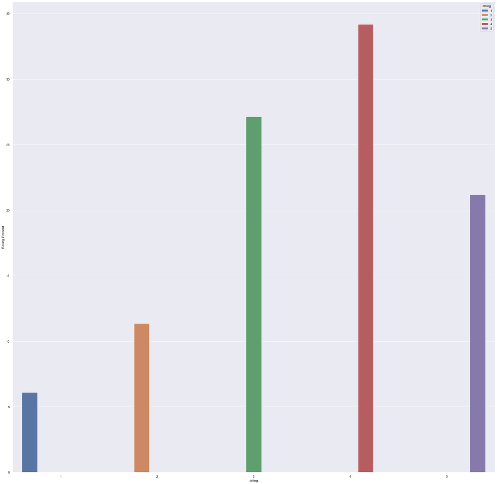

```python
ax = sns.barplot(x="rating", y="rating", data=ratings, estimator=lambda x: len(x) / len(ratings) * 100, hue = 'rating')
ax.set(ylabel="Rating Percent")
```

```
[Text(0, 0.5, 'Gender Percent')]
```

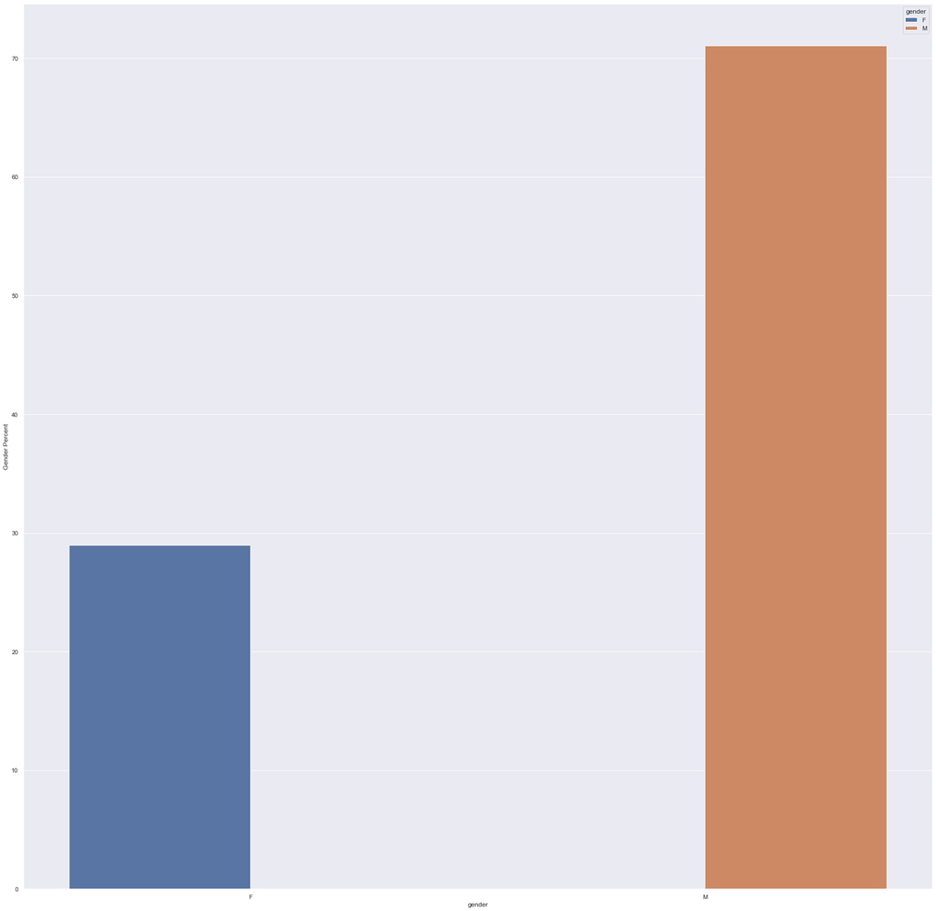

```python
groupedresult = users.groupby(['gender']).count().reset_index()
groupedresult['percent'] = groupedresult['user id']/groupedresult['user id'].sum() * 100
ax = sns.barplot(x='gender',y='percent',data=groupedresult, hue='gender')
ax.set(ylabel="Gender Percent")
plt.show()
```

```
[Text(0, 0.5, 'Occupation Percent')]
```

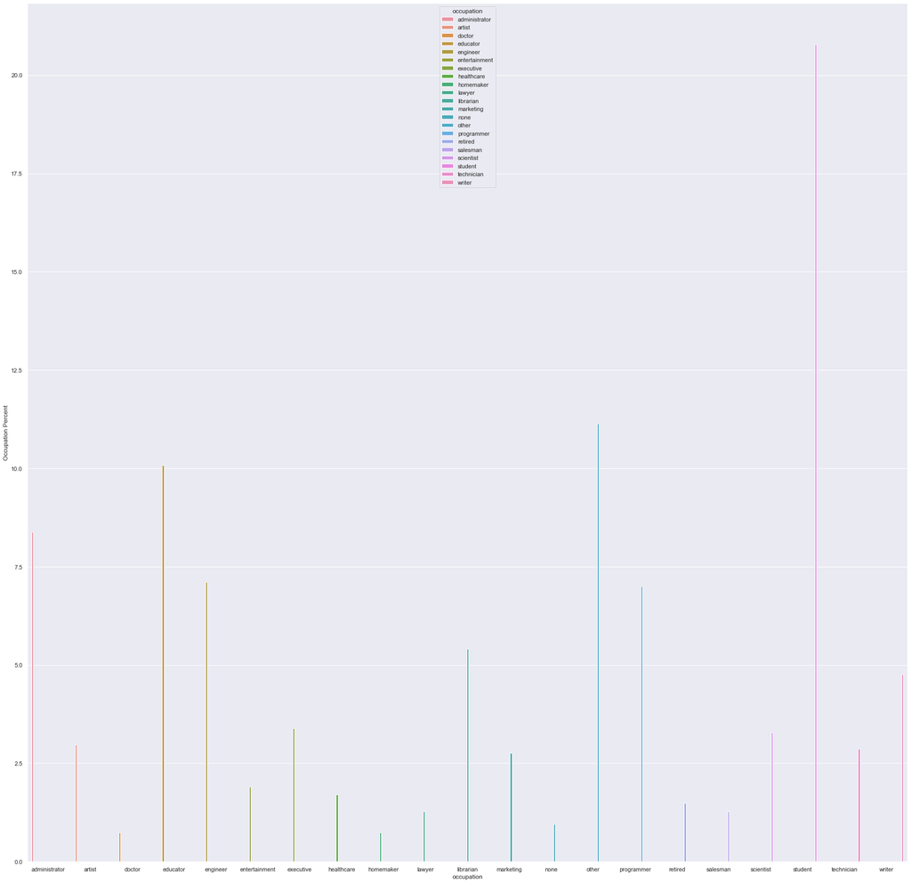

```python
groupedresult = users.groupby(['occupation']).count().reset_index()
groupedresult['percent'] = groupedresult['user id']/groupedresult['user id'].sum() * 100
ax = sns.barplot(x='occupation',y='percent',data=groupedresult, hue='occupation')
ax.set(ylabel="Occupation Percent")
plt.show()
```

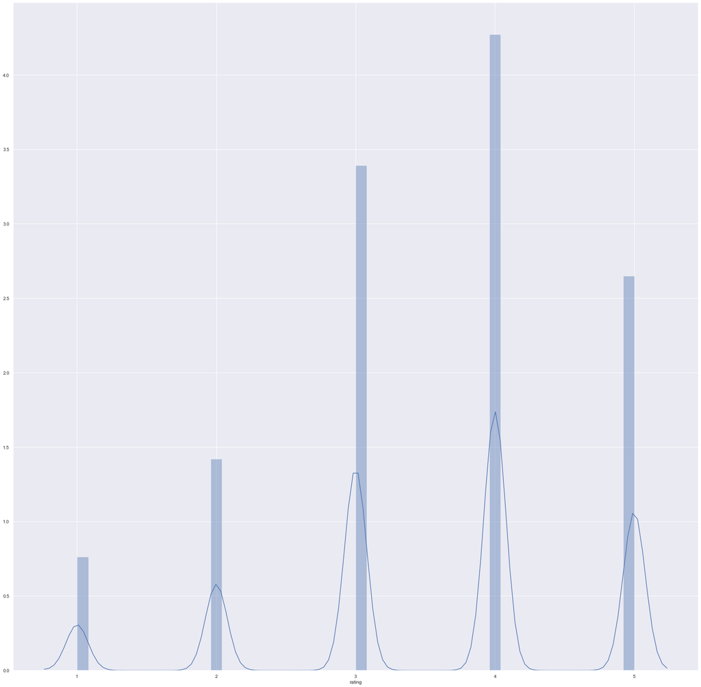

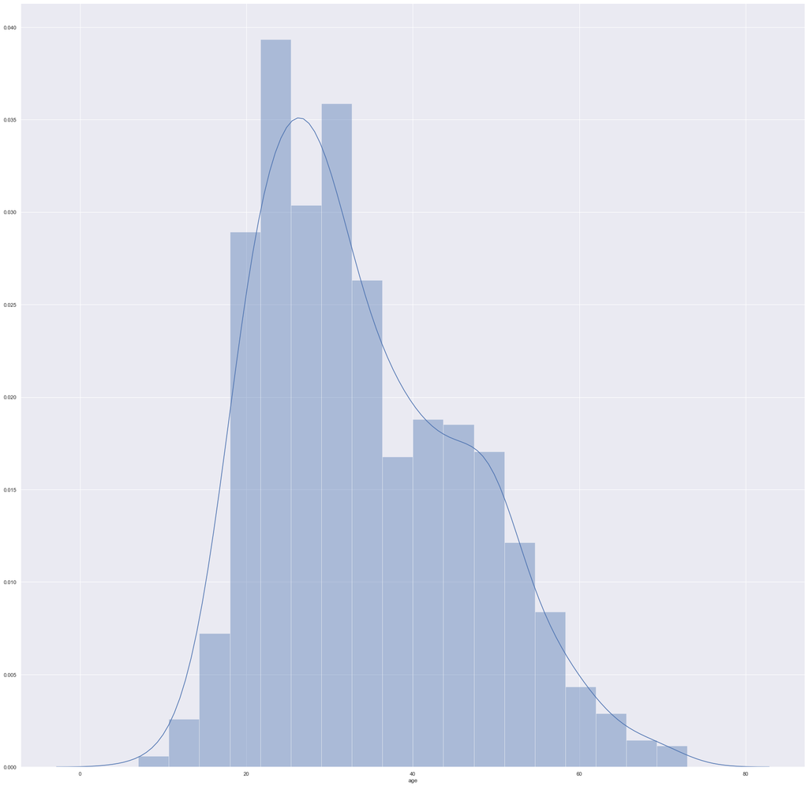

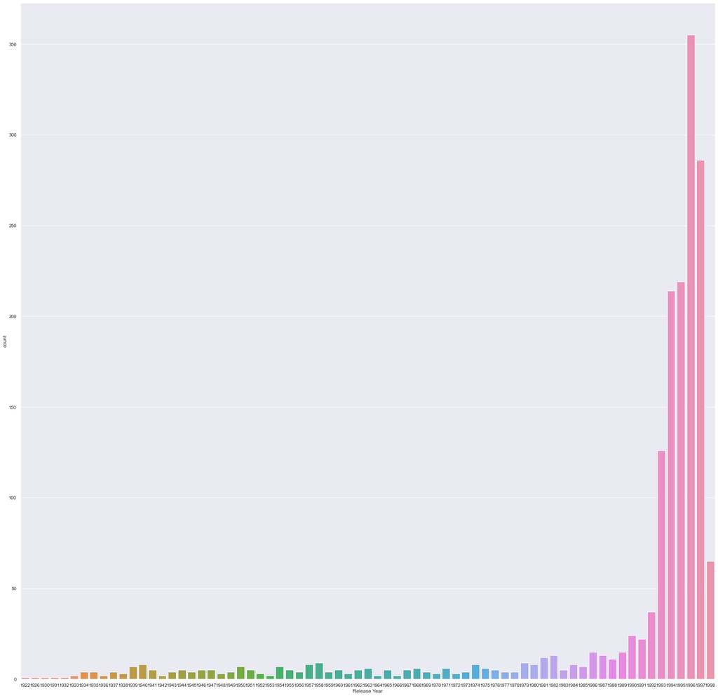

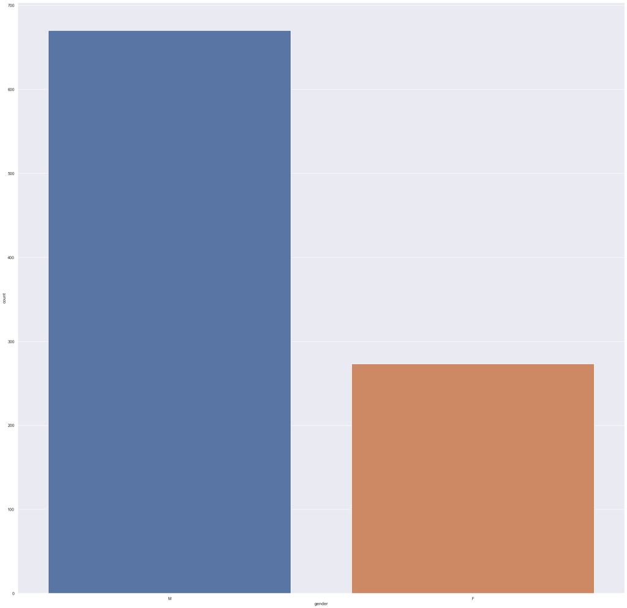

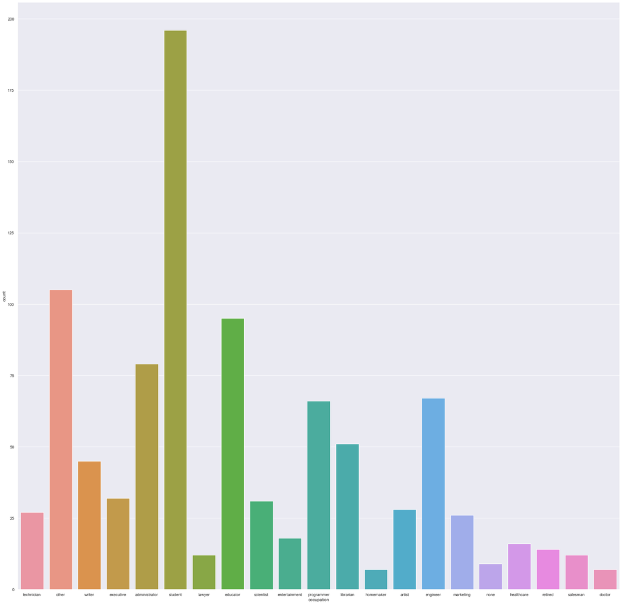

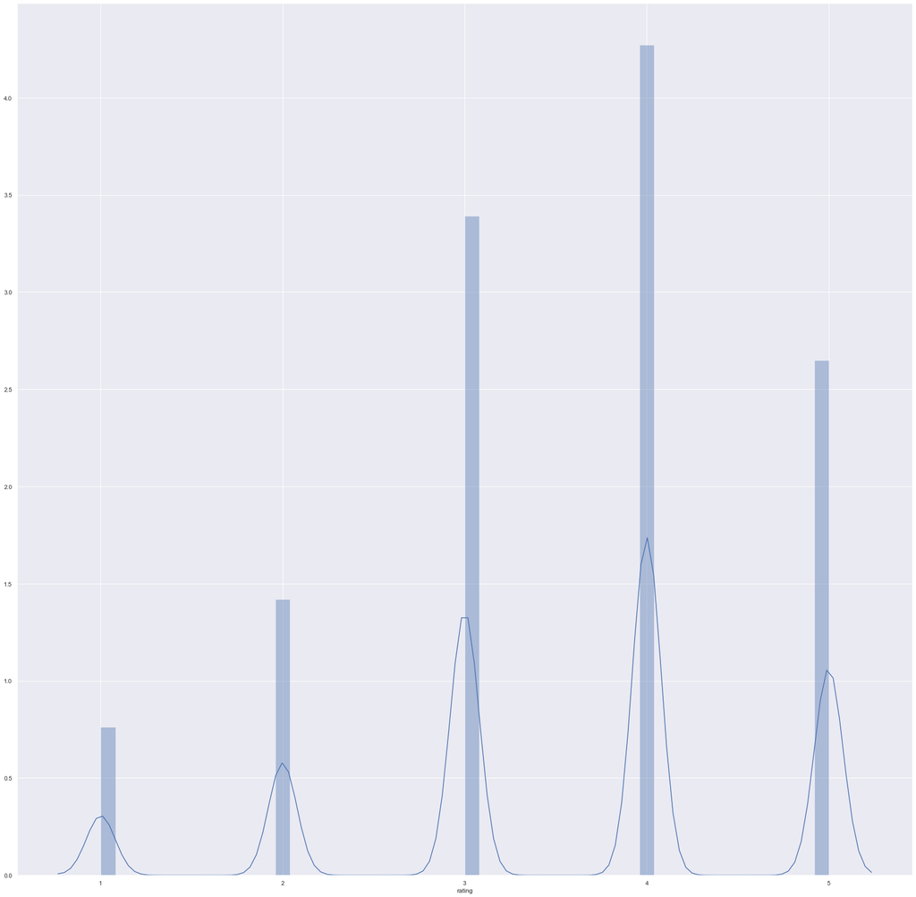

```python
# Add a new Column for Release Year and use a Lambda to split the date and get the year
movies['Release Year'] = movies.apply(lambda row : row['release date'].split('-')[2], axis = 1)

sns.distplot(ratings['rating'])
plt.show()


# distplot for Age
sns.distplot(users['age'])
plt.show()


# countplots
sns.countplot(x="Release Year", data=movies)
plt.show()

sns.countplot(x="gender", data=users)
plt.show()

sns.countplot(x="occupation", data=users)
plt.show()

sns.distplot(ratings['rating'])
plt.show()
```

### 8. Visualize how popularity of genres has changed over the years - 10 marks

Note that you need to use the **percent of number of releases in a year** as a parameter of popularity of a genre

Hint 1: You need to reach to a data frame where the release year is the index and the genre is the column names (one cell shows the number of release in a year in one genre) or vice versa. (Drop unnecessary column if there are any)

Hint 2: Find the total number of movies release in a year(use `sum(axis=1)` store that value in a new column as 'total'). Now divide the value of each genre in that year by total to get percentage number of release in a particular year. `(df.div(df['total'], axis= 0) * 100)`

Once that is achieved, you can either use univariate plots or can use the heatmap to visualise all the changes over the years in one go.

Hint 3: Use groupby on the relevant column and use sum() on the same to find out the number of releases in a year/genre.

|  | Release Year | Action | Adventure | Animation | Childrens | Comedy | Crime | Documentary | Drama | Fantasy | ... | Horror | Musical | Mystery | Romance | Sci-Fi | Thriller | War | Western | Genre Count | total |
| --- | --- | --- | --- | --- | --- | --- | --- | --- | --- | --- | --- | --- | --- | --- | --- | --- | --- | --- | --- | --- | --- |
| 0 | 1922 | 0 | 0 | 0 | 0 | 0 | 0 | 0 | 0 | 0 | ... | 1 | 0 | 0 | 0 | 0 | 0 | 0 | 0 | 1 | 2 |
| 1 | 1926 | 0 | 0 | 0 | 0 | 0 | 0 | 0 | 1 | 0 | ... | 0 | 0 | 0 | 0 | 0 | 0 | 0 | 0 | 1 | 2 |
| 2 | 1930 | 0 | 0 | 0 | 0 | 0 | 0 | 0 | 1 | 0 | ... | 0 | 0 | 0 | 0 | 0 | 0 | 0 | 0 | 1 | 2 |
| 3 | 1931 | 0 | 0 | 0 | 0 | 0 | 1 | 0 | 0 | 0 | ... | 0 | 0 | 0 | 0 | 0 | 1 | 0 | 0 | 3 | 6 |
| 4 | 1932 | 0 | 0 | 0 | 0 | 0 | 0 | 0 | 0 | 0 | ... | 0 | 0 | 0 | 1 | 0 | 0 | 1 | 0 | 2 | 4 |
| ... | ... | ... | ... | ... | ... | ... | ... | ... | ... | ... | ... | ... | ... | ... | ... | ... | ... | ... | ... | ... | ... |
| 66 | 1994 | 30 | 13 | 4 | 15 | 82 | 8 | 9 | 97 | 3 | ... | 8 | 2 | 2 | 35 | 7 | 25 | 7 | 6 | 347 | 700 |
| 67 | 1995 | 40 | 22 | 6 | 21 | 63 | 11 | 5 | 89 | 3 | ... | 14 | 3 | 5 | 37 | 15 | 39 | 5 | 2 | 379 | 760 |
| 68 | 1996 | 44 | 24 | 9 | 21 | 108 | 21 | 18 | 170 | 6 | ... | 11 | 9 | 6 | 38 | 15 | 47 | 9 | 2 | 557 | 1116 |
| 69 | 1997 | 46 | 20 | 3 | 22 | 87 | 30 | 6 | 113 | 4 | ... | 8 | 5 | 18 | 51 | 13 | 54 | 14 | 0 | 496 | 992 |
| 70 | 1998 | 12 | 3 | 0 | 1 | 13 | 7 | 3 | 33 | 1 | ... | 4 | 1 | 3 | 11 | 5 | 18 | 0 | 0 | 117 | 234 |

71 rows × 21 columns

|  | Release Year | Action | Adventure | Animation | Childrens | Comedy | Crime | Documentary | Drama | Fantasy | ... | Horror | Musical | Mystery | Romance | Sci-Fi | Thriller | War | Western | Genre Count | total |
| --- | --- | --- | --- | --- | --- | --- | --- | --- | --- | --- | --- | --- | --- | --- | --- | --- | --- | --- | --- | --- | --- |
| 0 | 1922 | 0.000000 | 0.000000 | 0.000000 | 0.000000 | 0.000000 | 0.000000 | 0.000000 | 0.000000 | 0.000000 | ... | 50.000000 | 0.000000 | 0.000000 | 0.000000 | 0.000000 | 0.000000 | 0.000000 | 0.000000 | 50.000000 | 2 |
| 1 | 1926 | 0.000000 | 0.000000 | 0.000000 | 0.000000 | 0.000000 | 0.000000 | 0.000000 | 50.000000 | 0.000000 | ... | 0.000000 | 0.000000 | 0.000000 | 0.000000 | 0.000000 | 0.000000 | 0.000000 | 0.000000 | 50.000000 | 2 |
| 2 | 1930 | 0.000000 | 0.000000 | 0.000000 | 0.000000 | 0.000000 | 0.000000 | 0.000000 | 50.000000 | 0.000000 | ... | 0.000000 | 0.000000 | 0.000000 | 0.000000 | 0.000000 | 0.000000 | 0.000000 | 0.000000 | 50.000000 | 2 |
| 3 | 1931 | 0.000000 | 0.000000 | 0.000000 | 0.000000 | 0.000000 | 16.666667 | 0.000000 | 0.000000 | 0.000000 | ... | 0.000000 | 0.000000 | 0.000000 | 0.000000 | 0.000000 | 16.666667 | 0.000000 | 0.000000 | 50.000000 | 6 |
| 4 | 1932 | 0.000000 | 0.000000 | 0.000000 | 0.000000 | 0.000000 | 0.000000 | 0.000000 | 0.000000 | 0.000000 | ... | 0.000000 | 0.000000 | 0.000000 | 25.000000 | 0.000000 | 0.000000 | 25.000000 | 0.000000 | 50.000000 | 4 |
| ... | ... | ... | ... | ... | ... | ... | ... | ... | ... | ... | ... | ... | ... | ... | ... | ... | ... | ... | ... | ... | ... |
| 66 | 1994 | 4.285714 | 1.857143 | 0.571429 | 2.142857 | 11.714286 | 1.142857 | 1.285714 | 13.857143 | 0.428571 | ... | 1.142857 | 0.285714 | 0.285714 | 5.000000 | 1.000000 | 3.571429 | 1.000000 | 0.857143 | 49.571429 | 700 |
| 67 | 1995 | 5.263158 | 2.894737 | 0.789474 | 2.763158 | 8.289474 | 1.447368 | 0.657895 | 11.710526 | 0.394737 | ... | 1.842105 | 0.394737 | 0.657895 | 4.868421 | 1.973684 | 5.131579 | 0.657895 | 0.263158 | 49.868421 | 760 |
| 68 | 1996 | 3.942652 | 2.150538 | 0.806452 | 1.881720 | 9.677419 | 1.881720 | 1.612903 | 15.232975 | 0.537634 | ... | 0.985663 | 0.806452 | 0.537634 | 3.405018 | 1.344086 | 4.211470 | 0.806452 | 0.179211 | 49.910394 | 1116 |
| 69 | 1997 | 4.637097 | 2.016129 | 0.302419 | 2.217742 | 8.770161 | 3.024194 | 0.604839 | 11.391129 | 0.403226 | ... | 0.806452 | 0.504032 | 1.814516 | 5.141129 | 1.310484 | 5.443548 | 1.411290 | 0.000000 | 50.000000 | 992 |
| 70 | 1998 | 5.128205 | 1.282051 | 0.000000 | 0.427350 | 5.555556 | 2.991453 | 1.282051 | 14.102564 | 0.427350 | ... | 1.709402 | 0.427350 | 1.282051 | 4.700855 | 2.136752 | 7.692308 | 0.000000 | 0.000000 | 50.000000 | 234 |

71 rows × 21 columns

| Release Year | Action | Adventure | Animation | Childrens | Comedy | Crime | Documentary | Drama | Fantasy | Film-Noir | Horror | Musical | Mystery | Romance | Sci-Fi | Thriller | War | Western | Genre Count | total |
| --- | --- | --- | --- | --- | --- | --- | --- | --- | --- | --- | --- | --- | --- | --- | --- | --- | --- | --- | --- | --- |
| 1922 | 0 | 0 | 0 | 0 | 0 | 0 | 0 | 0 | 0 | 0 | 1 | 0 | 0 | 0 | 0 | 0 | 0 | 0 | 1 | 2 |
| 1926 | 0 | 0 | 0 | 0 | 0 | 0 | 0 | 1 | 0 | 0 | 0 | 0 | 0 | 0 | 0 | 0 | 0 | 0 | 1 | 2 |
| 1930 | 0 | 0 | 0 | 0 | 0 | 0 | 0 | 1 | 0 | 0 | 0 | 0 | 0 | 0 | 0 | 0 | 0 | 0 | 1 | 2 |
| 1931 | 0 | 0 | 0 | 0 | 0 | 1 | 0 | 0 | 0 | 1 | 0 | 0 | 0 | 0 | 0 | 1 | 0 | 0 | 3 | 6 |
| 1932 | 0 | 0 | 0 | 0 | 0 | 0 | 0 | 0 | 0 | 0 | 0 | 0 | 0 | 1 | 0 | 0 | 1 | 0 | 2 | 4 |
| ... | ... | ... | ... | ... | ... | ... | ... | ... | ... | ... | ... | ... | ... | ... | ... | ... | ... | ... | ... | ... |
| 1994 | 30 | 13 | 4 | 15 | 82 | 8 | 9 | 97 | 3 | 0 | 8 | 2 | 2 | 35 | 7 | 25 | 7 | 6 | 347 | 700 |
| 1995 | 40 | 22 | 6 | 21 | 63 | 11 | 5 | 89 | 3 | 1 | 14 | 3 | 5 | 37 | 15 | 39 | 5 | 2 | 379 | 760 |
| 1996 | 44 | 24 | 9 | 21 | 108 | 21 | 18 | 170 | 6 | 1 | 11 | 9 | 6 | 38 | 15 | 47 | 9 | 2 | 557 | 1116 |
| 1997 | 46 | 20 | 3 | 22 | 87 | 30 | 6 | 113 | 4 | 2 | 8 | 5 | 18 | 51 | 13 | 54 | 14 | 0 | 496 | 992 |
| 1998 | 12 | 3 | 0 | 1 | 13 | 7 | 3 | 33 | 1 | 2 | 4 | 1 | 3 | 11 | 5 | 18 | 0 | 0 | 117 | 234 |

71 rows × 20 columns

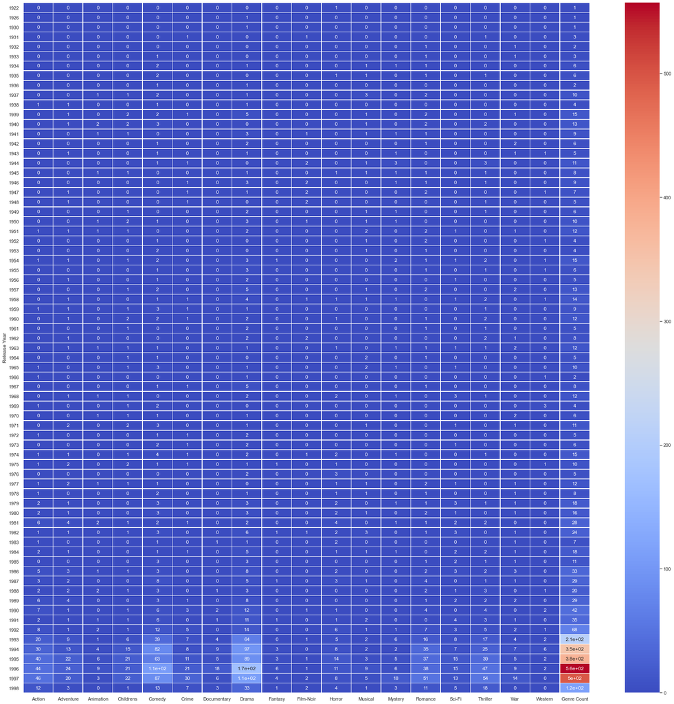

```python
# Setting the Index to Release Year so we can perform aggregation
movies_df1 = movies.set_index('Release Year')

# Remove unused columns
movies_df2 = movies_df1.drop(['movie id','movie title','release date','unknown'], axis=1)

# Aggregate all the rows with the same Release Year
movies_df3 = movies_df2.groupby(['Release Year']).agg('sum')

# Find the count of movies released per year
movies_df3['total'] = movies_df3.sum(axis=1)
movies_df4 = movies_df3.reset_index()
movies_df4.head(10000)

# Find Percentage of each genre for a particular year
movies_df5 = movies_df3.apply(lambda x: x/(movies_df3['total']) * 100 if x.name != 'total' else x)
movies_df6 = movies_df5.reset_index()
movies_df6

# Plots to identify how popularity of genres have changed
movies_df3


movies_df11 = movies_df3.drop('total', axis=1)
sns.heatmap(movies_df11,annot=True,linewidth = 0.5, cmap='coolwarm') # the color intensity is based on
plt.show()
```

Hints :

1. Find the count of ratings and average ratings for every movie.
2. Slice the movies which have ratings more than 100.
3. Sort values according to average rating such that movie which highest rating is on top.
4. Select top 25 movies.
5. You will have to use the .merge() function to get the movie titles.

Note: This question will need you to research about groupby and apply your findings. You can find more on groupby on https://realpython.com/pandas-groupby/.

```python
# 1 Count of Ratings for every movie
ratings_df1 = ratings.groupby(['movie id'])['rating'].count()
ratings_df2 = ratings_df1.to_frame().merge(movies, on = 'movie id')[['movie title','rating']]
ratings_df2
```

|  | movie title | rating |
| --- | --- | --- |
| 0 | Toy Story | 452 |
| 1 | GoldenEye | 131 |
| 2 | Four Rooms | 90 |
| 3 | Get Shorty | 209 |
| 4 | Copycat | 86 |
| ... | ... | ... |
| 1675 | Mat' i syn | 1 |
| 1676 | B. Monkey | 1 |
| 1677 | Sliding Doors | 1 |
| 1678 | You So Crazy | 1 |
| 1679 | Scream of Stone (Schrei aus Stein) | 1 |

1680 rows × 2 columns

```python
# Avg rating for each movie
ratings_df3 = ratings.groupby(['movie id'])['rating'].agg('mean')
ratings_df4 = ratings_df3.to_frame().merge(movies, on = 'movie id')[['movie title','rating']]
ratings_df4
```

|  | movie title | rating |
| --- | --- | --- |
| 0 | Toy Story | 3.878319 |
| 1 | GoldenEye | 3.206107 |
| 2 | Four Rooms | 3.033333 |
| 3 | Get Shorty | 3.550239 |
| 4 | Copycat | 3.302326 |
| ... | ... | ... |
| 1675 | Mat' i syn | 1.000000 |
| 1676 | B. Monkey | 3.000000 |
| 1677 | Sliding Doors | 2.000000 |
| 1678 | You So Crazy | 3.000000 |
| 1679 | Scream of Stone (Schrei aus Stein) | 3.000000 |

1680 rows × 2 columns

```python
# 2 Slice the movies which have ratings more than 100.
ratings_df5 = ratings_df2[ratings_df2['rating'] > 100]
ratings_df5
```

|  | movie title | rating |
| --- | --- | --- |
| 0 | Toy Story | 452 |
| 1 | GoldenEye | 131 |
| 3 | Get Shorty | 209 |
| 6 | Twelve Monkeys | 392 |
| 7 | Babe | 219 |
| ... | ... | ... |
| 924 | Down Periscope | 101 |
| 926 | Craft, The | 104 |
| 1014 | Con Air | 137 |
| 1026 | Grumpier Old Men | 148 |
| 1045 | Multiplicity | 134 |

334 rows × 2 columns

```python
# 3 Sort values according to average rating such that movie which highest rating is on top.
ratings_df6 = ratings_df4.sort_values(by = ['rating'], ascending = False)
ratings_df6
```

|  | movie title | rating |
| --- | --- | --- |
| 812 | Great Day in Harlem, A | 5.0 |
| 1596 | Someone Else's America | 5.0 |
| 1199 | Marlene Dietrich: Shadow and Light ( | 5.0 |
| 1120 | They Made Me a Criminal | 5.0 |
| 1650 | Entertaining Angels: The Dorothy Day Story | 5.0 |
| ... | ... | ... |
| 1565 | Vermont Is For Lovers | 1.0 |
| 1564 | Careful | 1.0 |
| 1563 | Man from Down Under, The | 1.0 |
| 1562 | Daens | 1.0 |
| 850 | Bloody Child, The | 1.0 |

1680 rows × 2 columns

```python
# 4 Select top 25 movies
ratings_df6.head(25)
```

|  | movie title | rating |
| --- | --- | --- |
| 812 | Great Day in Harlem, A | 5.000000 |
| 1596 | Someone Else's America | 5.000000 |
| 1199 | Marlene Dietrich: Shadow and Light ( | 5.000000 |
| 1120 | They Made Me a Criminal | 5.000000 |
| 1650 | Entertaining Angels: The Dorothy Day Story | 5.000000 |
| 1291 | Star Kid | 5.000000 |
| 1497 | Santa with Muscles | 5.000000 |
| 1187 | Prefontaine | 5.000000 |
| 1533 | Aiqing wansui | 5.000000 |
| 1464 | Saint of Fort Washington, The | 5.000000 |
| 1446 | Pather Panchali | 4.625000 |
| 118 | Maya Lin: A Strong Clear Vision | 4.500000 |
| 1395 | Anna | 4.500000 |
| 1639 | Some Mother's Son | 4.500000 |
| 1591 | Everest | 4.500000 |
| 406 | Close Shave, A | 4.491071 |
| 316 | Schindler's List | 4.466443 |
| 168 | Wrong Trousers, The | 4.466102 |
| 481 | Casablanca | 4.456790 |
| 113 | Wallace & Gromit: The Best of Aardman Animation | 4.447761 |
| 63 | Shawshank Redemption, The | 4.445230 |
| 601 | Rear Window | 4.387560 |
| 11 | Usual Suspects, The | 4.385768 |
| 49 | Star Wars | 4.358491 |
| 177 | 12 Angry Men | 4.344000 |

```python
# 5 You will have to use the .merge() function to get the movie titles.
# Used above
```